# RBIF111 - Homework 4

Neshita Kipuw

2024-11-05

```r
# Load necessary packages
library(ggplot2)
library(tidyr)
library(dplyr)
library(stats)
library(DESeq2)
library(reshape2)
library(data.table)
```

# 1 Question 1

The data set from UCI machine learning repository consists of a study on the donor database of Blood Transfusion Service Center in Hsin-Chu City in Taiwan. The center passes their blood transfusion service bus to one university in Hsin-Chu City to gather blood donated about every three months. The data contains 748 random donors from the donor database. The data features include continuous variables of: months since last donation, frequency (total number of donation event), total blood donated (in c.c.), months since first donation, and a classification variable representing whether donor donated blood in March 2007 (1 = donating blood; 0 = not donating blood).

```r
getwd()
```

```
## [1] "H:/My Drive/RBIF111/wk4"
```

```r
# Read in the data as CSV and name all the columns
blood_dataset <- read.csv("transfusion.data", header = TRUE)
names(blood_dataset) <- c("last_donation", "frequency", "total_donation", "first_donation", "outcome")
head(blood_dataset)
```

```
##   last_donation frequency total_donation first_donation outcome
## 1             2        50          12500             98       1
## 2             0        13           3250             28       1
## 3             1        16           4000             35       1
## 4             2        20           5000             45       1
## 5             1        24           6000             77       0
## 6             4         4           1000              4       0
```

```r
##Partition data set based on hospital outcome
partition_data <- function(data){
    #Partition the data set into two based on outcome
    partition_data <- split(data, data$outcome)

    # Convert the list to a data frame
    df_0 <- partition_data[[1]]
    df_1 <- partition_data[[2]]

    # Add a column to identify the group
    df_0$group <- "No blood donation"
    df_1$group <- "Donate blood"

    # Combine the two data frames
    result_df <- rbind(df_0, df_1)

    return(result_df)
}
# Execute the function
blood_data <- partition_data(blood_dataset)
head(blood_data)
```

```
##    last_donation frequency total_donation first_donation outcome
## 5              1        24           6000             77       0
## 6              4         4           1000              4       0
## 8              1        12           3000             35       0
## 11             4        23           5750             58       0
## 12             0         3            750              4       0
## 14             1        13           3250             47       0
##                group
## 5  No blood donation
## 6  No blood donation
## 8  No blood donation
## 11 No blood donation
## 12 No blood donation
## 14 No blood donation
```

Check whether the continuous data variables are normally distributed

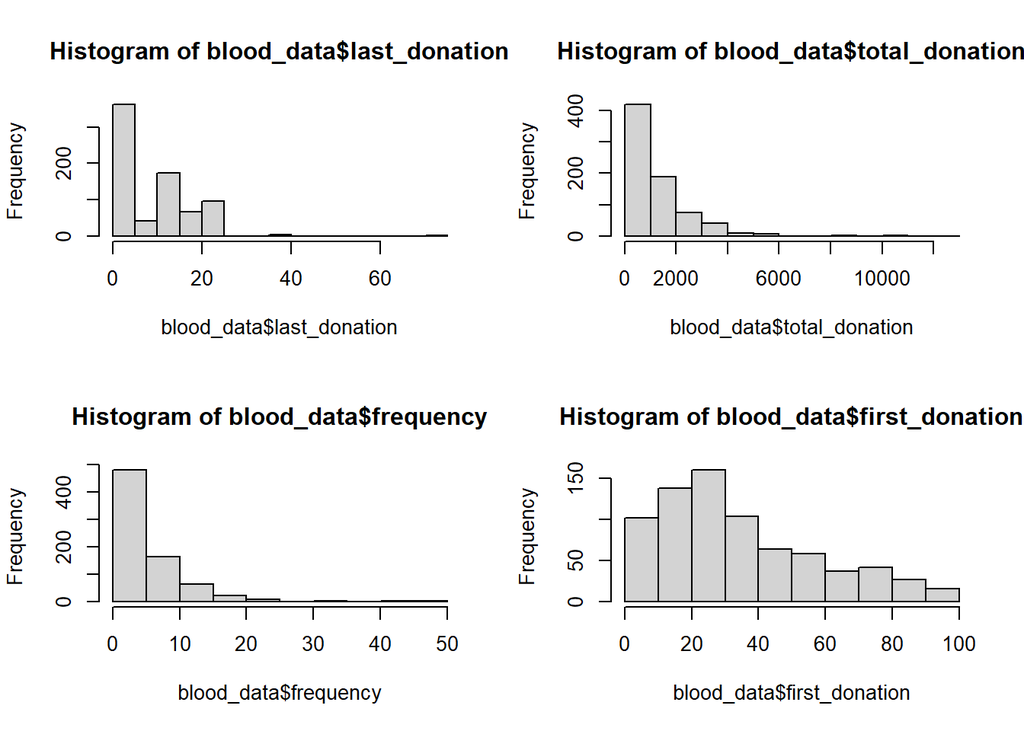

It seems none of the continuous data variables are normally distributed, therefore the *Wilcoxon test* will be used instead of the *t-test* for non-parametric data.

## 1.1 Random sampling and Wilcoxon test

The code below takes a random sample of N=30 measurement from continuous variable columns from the subset data that were partitioned by outcome. Then the mean difference is calculated and a 95% confidence interval is constructed for the difference using Wilcoxon test. This is done 1,000 times and all the confidence intervals are recorded.

```r
# Function to randomly sample and do non-parametric test
rsample_wcox <- function(data, column_name){
    #split data by group
    nondonor_grp <- data[data$group == "No blood donation", ]
    donor_grp <- data[data$group == "Donate blood", ]

    #take random sample
    nondonor_sample <- sample(nondonor_grp[[column_name]], size = 30, replace = FALSE)
    donor_sample <- sample(donor_grp[[column_name]], size = 30, replace = FALSE)

    #perform wilcoxon test
    wcox_result <- wilcox.test(nondonor_sample, donor_sample, conf.int = TRUE, conf.level = 0.95, exact = FALSE) #setting 'exact=FALSE' will eliminate ties#

    #Return mean difference and CI
    return(c(wcox_result$conf.int, mean_diff = mean(nondonor_sample) - mean(donor_sample)))
}
set.seed(123)
# Execute the function
blood_data1 <- replicate(1000, rsample_wcox(blood_data, "last_donation"))
blood_data2 <- replicate(1000, rsample_wcox(blood_data, "frequency"))
blood_data3 <- replicate(1000, rsample_wcox(blood_data, "total_donation"))
blood_data4 <- replicate(1000, rsample_wcox(blood_data, "first_donation"))

# Get CI & mean results for each variable
lower_CI1 <- blood_data1[1, ]
upper_CI1 <- blood_data1[2, ]
mean_diff1 <- blood_data1[3, ]

lower_CI2 <- blood_data2[1, ]
upper_CI2 <- blood_data2[2, ]
mean_diff2 <- blood_data2[3, ]

lower_CI3 <- blood_data3[1, ]
upper_CI3 <- blood_data3[2, ]
mean_diff3 <- blood_data3[3, ]

lower_CI4 <- blood_data4[1, ]
upper_CI4 <- blood_data4[2, ]
mean_diff4 <- blood_data4[3, ]
```

## 1.2 Results from random sampling and Wilcoxon test

### 1.2.1 a) The average lengths of the confidence interval for each variable:

```r
avg_CI4_len <- mean(upper_CI4 - lower_CI4)
avg_CI3_len <- mean(upper_CI3 - lower_CI3)
avg_CI2_len <- mean(upper_CI2 - lower_CI2)
avg_CI1_len <- mean(upper_CI1 - lower_CI1)

print(paste("The average length of the confidence interval for the last donation is =", format(round(avg_CI1_len, 3), nsmall = 3)))
```

```
## [1] "The average length of the confidence interval for the last donation is = 7.972"
```

```r
print(paste("The average length of the confidence interval for donation frequency is =", format(round(avg_CI2_len, 3), nsmall = 3)))
```

```
## [1] "The average length of the confidence interval for donation frequency is = 4.091"
```

```r
print(paste("The average length of the confidence interval for total blood donation is =", format(round(avg_CI3_len, 3), nsmall = 3)))
```

```
## [1] "The average length of the confidence interval for total blood donation is = 1012.000"
```

```r
print(paste("The average length of the confidence interval for the time since first donation is =", format(round(avg_CI4_len, 3), nsmall = 3)))
```

```
## [1] "The average length of the confidence interval for the time since first donation is = 23.557"
```

### 1.2.2 b) The population level difference (i.e., the difference between the means) for each variable:

```r
pop_diff4 <- mean(blood_data$first_donation[blood_data$group == "Donate blood"]) - mean(blood_data$first_donation[blood_data$group == "No blood donation"])
pop_diff3 <- mean(blood_data$total_donation[blood_data$group == "Donate blood"]) - mean(blood_data$total_donation[blood_data$group == "No blood donation"])
pop_diff2 <- mean(blood_data$frequency[blood_data$group == "Donate blood"]) - mean(blood_data$frequency[blood_data$group == "No blood donation"])
pop_diff1 <- mean(blood_data$last_donation[blood_data$group == "Donate blood"]) - mean(blood_data$last_donation[blood_data$group == "No blood donation"])

print(paste("The population level difference for the last donation is =", format(round(pop_diff1, 3), nsmall = 3)))
```

```
## [1] "The population level difference for the last donation is = -5.317"
```

```r
print(paste("The population level difference for donation frequency is =", format(round(pop_diff2, 3), nsmall = 3)))
```

```
## [1] "The population level difference for donation frequency is = 2.996"
```

```r
print(paste("The population level difference for total blood donation is =", format(round(pop_diff3, 3), nsmall = 3)))
```

```
## [1] "The population level difference for total blood donation is = 749.000"
```

```r
print(paste("The population level difference for the time since first donation is =", format(round(pop_diff4, 3), nsmall = 3)))
```

```
## [1] "The population level difference for the time since first donation is = -2.051"
```

### 1.2.3 c) How often the confidence intervals contain the population level difference for each variable:

```r
freq_poplevel4 <- mean(lower_CI4 < pop_diff4 & upper_CI4 > pop_diff4)

freq_poplevel3 <- mean(lower_CI3 < pop_diff3 & upper_CI3 > pop_diff3)

freq_poplevel2 <- mean(lower_CI2 < pop_diff2 & upper_CI2 > pop_diff2)

freq_poplevel1 <- mean(lower_CI1 < pop_diff1 & upper_CI1 > pop_diff1)

print(paste("The frequency that the CI contains the population level difference is =", format(round(freq_poplevel1, 3), nsmall = 3)))
```

```
## [1] "The frequency that the CI contains the population level difference is = 0.000"
```

```r
print(paste("The frequency that the CI contains the population level difference is =", format(round(freq_poplevel2, 3), nsmall = 3)))
```

```
## [1] "The frequency that the CI contains the population level difference is = 0.006"
```

```r
print(paste("The frequency that the CI contains the population level difference is =", format(round(freq_poplevel3, 3), nsmall = 3)))
```

```
## [1] "The frequency that the CI contains the population level difference is = 0.004"
```

```r
print(paste("The frequency that the CI contains the population level difference is =", format(round(freq_poplevel4, 3), nsmall = 3)))
```

```
## [1] "The frequency that the CI contains the population level difference is = 0.888"
```

## 1.3 Non-random sampling and Wilcoxon test analysis for the entire data for each variable

The code below will calculate the confidence interval for the full data set of each variable. Wilcoxon test will be used due to skewed distribution of the variables. The result is the lower and upper confidence interval values for each variable, along with the differences in mean.

```r
rsample_wcox2 <- function(data, column_name){
    #split data by group
    nondonor_grp <- data[data$group == "No blood donation", ]
    donor_grp <- data[data$group == "Donate blood", ]

    # get all the data per group
    nondonor_sample <- nondonor_grp[[column_name]]
    donor_sample <- donor_grp[[column_name]]

    #perform Wilcoxon test
    wcox_result <- wilcox.test(nondonor_sample, donor_sample, conf.int = TRUE, conf.level = 0.95, exact = FALSE) #setting 'exact = FALSE' will eliminate ties#

    #Return mean difference and CI
    return(c(wcox_result$conf.int, mean_diff = mean(nondonor_sample) - mean(donor_sample)))
}

set.seed(123)
# Execute the function for each variable
blood_data5 <- rsample_wcox2(blood_data, "last_donation")
blood_data6 <- rsample_wcox2(blood_data, "frequency")
blood_data7 <- rsample_wcox2(blood_data, "total_donation")
blood_data8 <- rsample_wcox2(blood_data, "first_donation")

# Get CI & mean results for full dataset
lower_CI5 <- blood_data5[1]
upper_CI5 <- blood_data5[2]
mean_diff5 <- blood_data5[3]

lower_CI6 <- blood_data6[1]
upper_CI6 <- blood_data6[2]
mean_diff6 <- blood_data6[3]

lower_CI7 <- blood_data7[1]
upper_CI7 <- blood_data7[2]
mean_diff7 <- blood_data7[3]

lower_CI8 <- blood_data8[1]
upper_CI8 <- blood_data8[2]
mean_diff8 <- blood_data8[3]
```

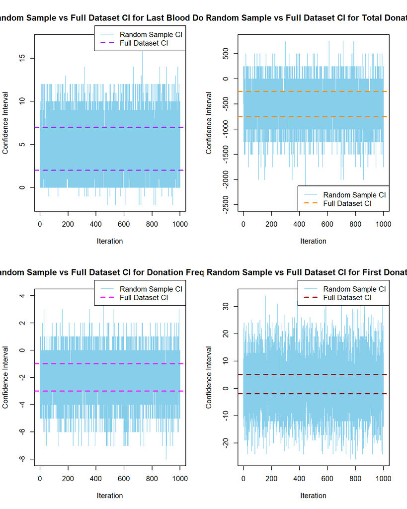

```r
# Visualize data
par(mfcol = c(2,2))
par(xpd=FALSE)

## Plot last blood donation
plot(1:1000, blood_data1[3,], ylim = range(c(blood_data1[1,], blood_data1[2,])),
     type = "n", xlab = "Iteration", ylab = "Confidence Interval",
     main = "Random Sample vs Full Dataset CI for Last Blood Donation")
# Add random sample CI
segments(1:1000, blood_data1[1,], 1:1000, blood_data1[2,], col = "skyblue", alpha = 0.1)
# Add full dataset CI as horizontal lines
abline(h = lower_CI5, col = "purple", lwd = 2, lty = 2)
abline(h = upper_CI5, col = "purple", lwd = 2, lty = 2)
# Add legend
par(xpd=TRUE)
legend("topright", inset = c(0, -0.05), legend = c("Random Sample CI", "Full Dataset CI"),
       col = c("skyblue", "purple"), lty = c(1, 2), lwd = c(1, 2))

## Plot frequency of blood donation
par(xpd=FALSE)
plot(1:1000, blood_data2[3,], ylim = range(c(blood_data2[1,], blood_data2[2,])),
     type = "n", xlab = "Iteration", ylab = "Confidence Interval",
     main = "Random Sample vs Full Dataset CI for Donation Frequency")
# Add random sample CI
segments(1:1000, blood_data2[1,], 1:1000, blood_data2[2,], col = "skyblue", alpha = 0.1)
# Add full dataset CI as horizontal lines
abline(h = lower_CI6, col = "magenta", lwd = 2, lty = 2)
abline(h = upper_CI6, col = "magenta", lwd = 2, lty = 2)
# Add legend
par(xpd=TRUE)
legend("topright", inset = c(0, -0.05), legend = c("Random Sample CI", "Full Dataset CI"),
       col = c("skyblue", "magenta"), lty = c(1, 2), lwd = c(1, 2))

## Plot total blood donation
par(xpd=FALSE)
plot(1:1000, blood_data3[3,], ylim = range(c(blood_data3[1,], blood_data3[2,])),
     type = "n", xlab = "Iteration", ylab = "Confidence Interval",
     main = "Random Sample vs Full Dataset CI for Total Donation")
# Add random sample CI
segments(1:1000, blood_data3[1,], 1:1000, blood_data3[2,], col = "skyblue", alpha = 0.1)
# Add full dataset CI as horizontal lines
abline(h = lower_CI7, col = "darkorange", lwd = 2, lty = 2)
abline(h = upper_CI7, col = "darkorange", lwd = 2, lty = 2)
# Add legend
par(xpd=TRUE)
legend("bottomright", inset = c(0,0), legend = c("Random Sample CI", "Full Dataset CI"),
       col = c("skyblue", "darkorange"), lty = c(1, 2), lwd = c(1, 2))

## Plot time since first blood donation
par(xpd=FALSE)
plot(1:1000, blood_data4[3,], ylim = range(c(blood_data4[1,], blood_data4[2,])),
     type = "n", xlab = "Iteration", ylab = "Confidence Interval",
     main = "Random Sample vs Full Dataset CI for First Donation")
# Add random sample CI
segments(1:1000, blood_data4[1,], 1:1000, blood_data4[2,], col = "skyblue", alpha = 0.1)
# Add full dataset CI as horizontal lines
abline(h = lower_CI8, col = "darkred", lwd = 2, lty = 2)
abline(h = upper_CI8, col = "darkred", lwd = 2, lty = 2)
# Add legend
par(xpd=TRUE)
legend("topright", inset = c(0, -0.05), legend = c("Random Sample CI", "Full Dataset CI"),
       col = c("skyblue", "darkred"), lty = c(1, 2), lwd = c(1, 2))
```

# 2 Question 2

The data obtained from GEO database is a study to identify the potential regulators in the progression of diabetic nephropathy (DN) using RNAseq of blood samples from healthy volunteers, patients with type-2 diabetes, and patients with DN. The data contains 14 total samples.

The code and results (hidden) below will download the data set from GEO database. *May collapse the code and results*

```r
#GEO download
GEODataDownload <- function(DS, gpl, gsm, PlateAnnotInfo, GenerateMetaData, Technology){
  library(DESeq2); library(data.table)
  if(Technology == "Array"){
    gset <- getGEO(DS)
    if(length(gset) > 1) idx <- grep(gpl, attr(gset, "names")) else idx <- 1
    gset <- gset[[idx]]
    fvarLabels(gset) <- make.names(fvarLabels(gset))
    comp <- gsub(" ", "", gsm)
    comp <- gsub(",", "", comp)
    gsms <- paste0(comp)
    #### Set up raw names ####
    sml <- c()
    for(i in 1:nchar(gsms)){ sml[i] <- substr(gsms,i,i)}
    ex <- exprs(gset)
    qx <- as.numeric(quantile(ex, c(0., 0.25, 0.5, 0.75, 0.99, 1.0), na.rm=T))
    LogC <- (qx[5] > 100) ||
      (qx[6]-qx[1] > 50 && qx[2] > 0) ||
      (qx[2] > 0 && qx[2] < 1 && qx[4] < 2)
    if(LogC){ ex[which(ex <= 0)] <- NaN
    exprs(gset) <- log2(ex) }
    sml <- paste("G", sml, sep="")
    f1 <- as.factor(sml)
    gset$description2 <- f1
    design <- model.matrix(~description2 + 0, gset)
    colnames(design) <- levels(f1)
    fit <- lmFit(gset, design)
    cont.matrix <- makeContrasts(G1-G0, levels = design)
    fit2 <- contrasts.fit(fit, cont.matrix)
    fit2 <- eBayes(fit2, 0.01)
    tT <- topTable(fit2, adjust="fdr", sort.by = "B", number = 25000000000)
    #### subset ####
    ex2 <- data.table(subset(tT, select=c("ID", "logFC", "P.Value", "adj.P.Val")))
    ex2$ID <- as.character(ex2$ID)
    #### annotate with gene names ####
    plat <- PlateAnnotInfo[GPLID == gpl,][,!"GPLID", with = FALSE]
    if(nrow(plat) == 0){ print(paste("There is no annotation information available for", gpl)) }
    plat$ID <- as.character(plat$ID)
    plat <- plat[!duplicated(plat$ID),]
    ex2 <- merge(plat, ex2, by = "ID")
    ex2$ID <- as.character(ex2$ID)
    exraw <- data.table(ex)
    exraw$ID <- as.character(rownames(ex))
    #### annotate raw data with gene names ####
    ex2 <- merge(ex2, exraw, by = "ID")
    #### Generate Meta Data ####
    Pdat <- pData(gset)
    #### Add Meta data ####
    Pdat <- as.data.table(Pdat)
    return(list(Data = ex2, MetaData = Pdat))
  }

  if(Technology == "RNAseq"){
    ACC <- paste("acc=", DS, sep = "")
    file <- paste("file=", DS, "_raw_counts_GRCh38.p13_NCBI.tsv.gz", sep = "")
    comp <- gsub(" ", "", gsm)
    comp <- gsub(",", "", comp)
    gsms <- paste0(comp)
    #### Set up DEG names ####
    urld <- "https://www.ncbi.nlm.nih.gov/geo/download/?format=file&type=rnaseq_counts"
    path <- paste(urld, ACC, file, sep="&");
    tbl <- as.matrix(data.table::fread(path, header=T, colClasses="integer"), rownames="GeneID")
    exraw <- tbl
    apath <- paste(urld, "type=rnaseq_counts", "file=Human.GRCh38.p13.annot.tsv.gz", sep="&")
    annot <- data.table::fread(apath, header=T, quote="", stringsAsFactors=F, data.table=F)
    rownames(annot) <- annot$GeneID
    sml <- strsplit(gsms, split="")[[1]]
    sel <- which(sml != "X")
    sml <- sml[sel]
    tbl <- tbl[ ,sel]
    gs <- factor(sml)
    groups <- make.names(c("Ctrl", "Tx"))
    levels(gs) <- groups
    sample_info <- data.frame(Group = gs, row.names = colnames(tbl))
    keep <- rowSums( tbl >= 10 ) >= min(table(gs))
    tbl <- tbl[keep, ]
    ds <- DESeqDataSetFromMatrix(countData=tbl, colData=sample_info, design= ~Group)

    # Estimate size factors and get normalized counts
    ds <- estimateSizeFactors(ds)
    # Continue with DESeq analysis
    ds <- DESeq(ds, test="Wald", sfType="poscount")
    normalized_counts <- counts(ds, normalized=TRUE)

    r <- results(ds, contrast=c("Group", groups[2], groups[1]), alpha=0.05, pAdjustMethod ="fdr")
    tT <- r[order(r$padj)[1:length(r$padj)],]
    tT <- merge(as.data.frame(tT), annot, by.x="row.names", by.y="GeneID", sort=F)
    tT <- subset(tT, select=c("Row.names","padj","pvalue","lfcSE","stat","log2FoldChange","baseMean","Symbol","Description"))

    #### subset ####
    ex2 <- data.table(subset(tT, select=c("Row.names", "Symbol", "Description", "log2FoldChange", "pvalue", "padj")))
    setnames(ex2, c("Row.names", "Symbol", "Description"), c("ENTREZID", "SYMBOL", "GENENAME"))

    #### Get Raw data ####
    exraw <- as.data.table(exraw)
    exraw$ENTREZID <- rownames(exraw)

    #### merge FC and raw data together ####
    mer <- merge(ex2, exraw, by = "ENTREZID")

    # Add normalized counts to the merged data
    normalized_counts_dt <- as.data.table(normalized_counts, keep.rownames = "ENTREZID")
    final_table <- merge(mer, normalized_counts_dt, by = "ENTREZID")

    return(final_table)
  }
}

# Execute the GEODataDownload function and obtain the RNAseq data set
RNAseqData <- GEODataDownload(DS = "GSE154881",
                              gpl = "GPL24676",
                              gsm = "00000111111111",
                              PlateAnnotInfo = "Only needed if the data was generated using MicroArrays",
                              GenerateMetaData = "Only needed if the data was generated using MicroArrays",
                              Technology = "RNAseq")
data.table(head(as.data.frame(RNAseqData),10), filter = 'top', options = list(pageLength = 10, scrollX = TRUE, scrollY = "400px", autoWidth = TRUE))

####Save the RNAseq data set to the working directory####
saveRDS(RNAseqData, file = "~/RNAseq_GSE154881_norm.rds")

####Reload the file into R environment####
GSE154881_norm <- readRDS("~/RNAseq_GSE154881_norm.rds")
```

The code below add new columns: group and subset comparison, for sample annotation.

```r
# Create a new data frame to group the samples by ctrl vs. Diabetic
new_df <- data.frame(
  Sample_ID = c("GSM4681806.y", "GSM4681807.y", "GSM4681808.y", "GSM4681809.y", "GSM4681810.y", "GSM4681811.y", "GSM4681812.y", "GSM4681813.y", "GSM4681814.y", "GSM4681815.y", "GSM4681816.y", "GSM4681817.y", "GSM4681818.y", "GSM4681820.y"),
  age = c(28,35,49,62,57,54,48,65,68,47,49,54,69,52),
  group = c("Ctrl", "Ctrl", "Ctrl", "Ctrl", "Ctrl", "Diabetic2", "Diabetic2", "Diabetic2", "Diabetic2", "Diabetic2", "Diabetic1", "Diabetic1", "Diabetic1", "Diabetic1")
)

# Convert data set to long format to merge the sample group
GSE154881_2 <- melt(GSE154881_norm, id.vars = c("ENTREZID", "SYMBOL", "GENENAME", "log2FoldChange", "pvalue", "padj"),
                           variable.name = "Sample_ID", value.name = "Expression")

# Merge the sample group to the long format data set and append the new column
GSE154881_2 <- merge(GSE154881_2, new_df, by = "Sample_ID", all.x = TRUE)

# Append the new column and use a placeholder value
GSE154881_2$Subset_Comparison <- "Unknown"

# Annotate the samples with correct sample groups
GSE154881_2$Subset_Comparison <- with(GSE154881_2,
    case_when(
        Sample_ID %in% c("GSM4681806.y", "GSM4681807.y", "GSM4681808.y", "GSM4681809.y", "GSM4681810.y") ~ "Healthy",
        Sample_ID %in% c("GSM4681811.y", "GSM4681812.y", "GSM4681813.y", "GSM4681814.y", "GSM4681815.y") ~ "Type2Diabetes",
        Sample_ID %in% c("GSM4681816.y", "GSM4681817.y", "GSM4681818.y", "GSM4681820.y") ~ "DiabeticNephropathy",
        TRUE ~ ""  # Default value for all other rows
    )
)

# Check the resulting converted data set
print(head(GSE154881_2))
```

```
## Key: <Sample_ID>
##       Sample_ID ENTREZID   SYMBOL
##          <char>   <AsIs>   <char>
## 1: GSM4681806.x        1     A1BG
## 2: GSM4681806.x      100      ADA
## 3: GSM4681806.x    10000     AKT3
## 4: GSM4681806.x    10001     MED6
## 5: GSM4681806.x    10004 NAALADL1
## 6: GSM4681806.x    10005    ACOT8
##                                               GENENAME log2FoldChange
##                                                 <char>          <num>
## 1:                              alpha-1-B glycoprotein      -1.160519
## 2:                                 adenosine deaminase      -1.185635
## 3:                       AKT serine/threonine kinase 3       1.044350
## 4:                          mediator complex subunit 6       1.772023
## 5: N-acetylated alpha-linked acidic dipeptidase like 1      -1.117207
## 6:                             acyl-CoA thioesterase 8      -1.893273
##          pvalue         padj Expression   age  group Subset_Comparison
##           <num>        <num>      <num> <num> <char>            <char>
## 1: 8.605488e-03 2.768009e-02         12    NA   <NA>
## 2: 5.847387e-03 2.078332e-02       6453    NA   <NA>
## 3: 1.793245e-02 4.723044e-02          0    NA   <NA>
## 4: 4.357661e-08 7.827448e-06          0    NA   <NA>
## 5: 2.625235e-02 6.294454e-02         62    NA   <NA>
## 6: 1.522098e-05 3.385843e-04          1    NA   <NA>
```

```r
print(tail(GSE154881_2))
```

```
## Key: <Sample_ID>
##       Sample_ID ENTREZID   SYMBOL                                   GENENAME
##          <char>   <AsIs>   <char>                                     <char>
## 1: GSM4681820.y     9989   PPP4R1 protein phosphatase 4 regulatory subunit 1
## 2: GSM4681820.y     9990  SLC12A6          solute carrier family 12 member 6
## 3: GSM4681820.y     9991    PTBP3     polypyrimidine tract binding protein 3
## 4: GSM4681820.y     9993    DGCR2   DiGeorge syndrome critical region gene 2
## 5: GSM4681820.y     9994 CASP8AP2             caspase 8 associated protein 2
## 6: GSM4681820.y     9997     SCO2        synthesis of cytochrome C oxidase 2
##    log2FoldChange       pvalue         padj Expression   age     group
##             <num>        <num>        <num>      <num> <num>    <char>
## 1:     0.04460707 9.106354e-01 0.9369106563   601.8536    52 Diabetic1
## 2:     0.16102863 7.021412e-01 0.7779605668  1042.7906    52 Diabetic1
## 3:     0.36365751 4.745762e-01 0.5819318855  1567.3535    52 Diabetic1
## 4:    -1.69743076 8.994351e-06 0.0002449913   704.0631    52 Diabetic1
## 5:     1.00208394 1.017186e-01 0.1781470090   168.0967    52 Diabetic1
## 6:    -2.16935640 4.294681e-05 0.0006530642   570.5995    52 Diabetic1
##      Subset_Comparison
##                 <char>
## 1: DiabeticNephropathy
## 2: DiabeticNephropathy
## 3: DiabeticNephropathy
## 4: DiabeticNephropathy
## 5: DiabeticNephropathy
## 6: DiabeticNephropathy
```